# Task 3: Classification

The aim of this notebook is to perform a **predictive analysis** in order to classify our customers in three categories (high-spending, low-spending and medium-spending) on the basis of their shopping behaviour.

We will run, compare and discuss the performance of 2 models:

- K-Nearest Neighbors
- Decision Tree

### Import basic libraries

```python
import statistics
import pandas as pd
import numpy as np
import matplotlib.pyplot as plt
from sklearn import metrics
```

### Import dataset

```python
cs = pd.read_csv('dataset/customers_num.csv', index_col=0)
cs_cat =  pd.read_csv('dataset/customers_cat.csv', index_col=0)
```

```python
cs['Country'] = cs_cat['Country']
cs['Fav_weekday'] = cs_cat['Fav_weekday']
cs['Fav_month'] = cs_cat['Fav_month']
```

```python
cs_num_columns = ['I', 'Iu', 'Imax', 'Ep', 'Eb', 'Stot', 'Smax', 'NSess']
```

### Transform categorical features into numerical ones

```python
#function to discretize the variables
#input: the dataset and the list of variables' names to discretize
def discretize_data(dataset, variables):
    for variable in variables:
        #get the unique variable's values
        var = sorted(dataset[variable].unique())

        #generate a mapping from the variable's values to the number representation
        mapping = dict(zip(var, range(0, len(var) + 1)))

        #add a new colum with the number representation of the variable
        dataset[variable+'_num'] = dataset[variable].map(mapping).astype(int)
    return dataset
```

```python
#discretize the categorical variables
variables = ['Country', 'Fav_weekday', 'Fav_month']
cs = discretize_data(cs, variables)
```

```python
#drop the categorical variables since we don't need them anymore
cs.drop(columns=['Country', 'Fav_weekday', 'Fav_month'], axis=1,inplace=True)
```

```python
#result
cs.info()
```

```
<class 'pandas.core.frame.DataFrame'>
Float64Index: 3646 entries, 13047.0 to 12713.0
Data columns (total 12 columns):
 #   Column           Non-Null Count  Dtype
---  ------           --------------  -----
 0   I                3646 non-null   int64
 1   Iu               3646 non-null   int64
 2   Imax             3646 non-null   int64
 3   Ep               3646 non-null   float64
 4   Eb               3646 non-null   float64
 5   Stot             3646 non-null   float64
 6   Smax             3646 non-null   float64
 7   Savg             3646 non-null   float64
 8   NSess            3646 non-null   int64
 9   Country_num      3646 non-null   int32
 10  Fav_weekday_num  3646 non-null   int32
 11  Fav_month_num    3646 non-null   int32
dtypes: float64(5), int32(3), int64(4)
memory usage: 327.6 KB
```

### Compute labels

Before proceeding with the execution of several classification algorithms, it is necessary to define the label on the basis of which setting up the **supervised learning** approach.

The indicator we choose to derive the label (i.e. the class: high, medium and low spending) is *Savg*.

Our choice falls on this attribute as it is the most representative of the customers' shopping profile: in fact it is calculated on the basis of the average amount spent by each customer during a shopping session. This means that the relevance of said attribute remains significant, wrt to the classification task, to both long-standing customers and brand-new ones without any prior interaction with the business entity.

**How to define the three classes:**

We identified two different ways in which define the three classes:

- **Using percentiles:**
- If Savg < 25% $\rightarrow $ low-spending customer
- If Savg > 75% $\rightarrow $ high-spending customer
- If 25% < Savg < 75% $\rightarrow $ medium-spending customer
- **Using quantiles:**
- If Savg < 0.33 $\rightarrow $ low-spending customer
- If Savg > 0.66 $\rightarrow $ high-spending customer
- If 0.33 < Savg < 0.66 $\rightarrow $ medium-spending customer

Among the two choices we pick the one providing the most balanced distribution of the customers among the three classes. By doing so we also avoid incrementing the relevance (or representation) of a particular class with respect to the others. Such premise is going to be confirmed in the choice of not using any kind of weight parameter during the classification task.

```python
# label tipo1
quantile_a = cs.Savg.quantile(0.33)
quantile_b = cs.Savg.quantile(0.66)
```

```python
labels = []
for customer, Savg in cs.Savg.items():
    if Savg < quantile_a:
        labels.append(0)
    elif Savg > quantile_b:
        labels.append(2)
    else:
        labels.append(1)
```

```python
cs.drop(columns=['Savg'], inplace=True)
```

```python
class_names = ['low-spending', 'medium-spending', 'high-spending']
```

#### Population of the classes

```python
classes = pd.DataFrame()
classes['labels'] = labels
classes.labels.value_counts()
```

```
2    1240
1    1203
0    1203
Name: labels, dtype: int64
```

The population is **almost equally distributed** among all the three labels. The support will therefore be, more or less, the same for all three classes. This will allow us to avoid using class weights.

### Preparing the training set and test set

```python
from sklearn.model_selection import train_test_split
train_set, test_set, train_label, test_label = train_test_split(cs, labels, stratify=labels, test_size=0.30)
```

### Aiding the implementation and evaluation of the classifiers with utility functions

```python
from sklearn.model_selection import GridSearchCV, RandomizedSearchCV
from sklearn.metrics import classification_report, make_scorer
from sklearn.metrics import accuracy_score, precision_score, recall_score
```

#### Print the classification scores

```python
def report_scores(test_label, test_pred):
    print(classification_report(test_label,
                            test_pred,
                            target_names=['low_spending', 'medium-spending', 'high-spending']))
```

#### Identify the misclassification of a classifier

```python
def spot_errors(test_label, test_pred):
    spot_errors = []
    for i in range(len(test_label)):
        if test_label[i] != test_pred[i]:
            spot_errors.append('darkred')
        else:
            spot_errors.append('darkgray')
    return spot_errors
```

#### Compares the true labels with the one predicted by a classifier while displaying the misclassification

```python
def classification_visualizer(test_set, test_label, test_pred, classifier_name):
    f, axs = plt.subplots(nrows=1, ncols=3, figsize=(24,8))
    a, b = 'I', 'Ep'
    errors = spot_errors(test_label, test_pred)
    labels = [test_label, test_pred, errors]
    titles = ['True Labels', 'Predicted Labels', 'Misclassifications']

    for i in range(3):
        axs[i].scatter(test_set[a], test_set[b], c=labels[i], s=20, cmap='cividis')
        axs[i].set_title(titles[i])
        axs[i].set_xlabel(a, fontdict={'fontsize': 'large'})
        axs[i].set_ylabel(b, fontdict={'fontsize': 'large'})

    plt.suptitle(('Visualization of the ' + classifier_name + ' classifier on the test set'),
                 fontsize=24, fontweight='bold')

    plt.show()
```

## Classifiers

### KNN (K-Nearest Neighbors)

**Neighbors-based classification** is a type of **instance-based learning** or **non-generalizing learning**: it does not attempt to construct a general internal model, but simply stores instances of the training data.

#### Import libraries

```python
from sklearn.neighbors import KNeighborsClassifier
```

#### Pre-processing

As for many of the classifiers, KNN works best with a dataset that is free of irrelevant and redundant attributes. The former add noise to the proximity measure while the latter introduce bias towards certain attributes. Ultimately, the classifier tends to benefit from dimensionality reduction and variable selection.

Additionally, attributes may need to be resized to prevent distance measurements from being dominated by one of the attributes. We now provide a normalized version of the training and test sets for use during some of the later tests on the classifier accuracy.

```python
from sklearn.preprocessing import MinMaxScaler
minmax_scaler = MinMaxScaler()
cs_norm_minmax = minmax_scaler.fit_transform(cs.values)
norm_train_set, norm_test_set, norm_train_label, norm_test_label = train_test_split(cs_norm_minmax, labels, stratify=labels, test_size=0.30)
```

#### Grid search

We proceed by using a grid search in order to identify the optimal values for parameters necessary for the execution of the classification task. The parameters are:

The number of neighbors, **K**:

- a small value for k induces a susceptibility to outliers and noise points;
- a large k makes the classification boundaries less defined;

We decide to analyze a range of 30 values starting from the closest single neighbor.

```python
k_range = range(1,31)
```

The **proximity metric**, used to calculate the distance between the points under analysis. In general it can be any metric measure, the standard Euclidean distance tends to be the most common choice but we decide to add other derivatives of the Minkowski Distance to the research:

- Euclidean distance (Minkowski Distance with p=2)
- Manhattan distance (Minkowski Distance with p=1)

```python
knn_metrics = ['euclidean', 'manhattan']
```

The **weight function** used when classifying unknown points, the method of using the class labels of the nearest neighbors K to determine the class label of the new record. The neighbors can contribute by:

- a majority vote
- by weighting the vote according to their distance from the new record

```python
knn_weights = ['uniform', 'distance']
```

The **algorithm** used to compute the nearest neighbors, it can be:

- brute, the most naive neighbor search implementation that involves the brute-force computation of distances between all pairs of points in the dataset (it can be very competitive for small data samples);
- kd_tree, short for K-dimensional tree, that tries to reduce the required number of distance calculations by encoding aggregate distance information for the sample (it is very fast for low-dimensional neighbors searches);
- ball_tree, that tries to address the inefficiencies of KD Trees in higher dimensions.

```python
knn_algorithms = ['ball_tree', 'kd_tree', 'brute']
```

The algorithm parameter also has the default value "auto", which means that the choice of the optimal algorithm is left to the classifier. Some tests are carried out to verify the reliability of this practice.

This is the parameters grid set up for the search.

```python
knn_param_grid = {
    'n_neighbors': k_range,
    'metric': knn_metrics,
    'algorithm': knn_algorithms,
    'weights': knn_weights
            }
```

We use the GridSearchCV function to implement the search. The cv parameters represent the number of folds employed within the cross validation of each possible set of values for the parameters described above. The scoring method employed to compare the different version of the classifier is the accuracy.

```python
knn_grid = GridSearchCV(KNeighborsClassifier(), knn_param_grid, cv=10, scoring='accuracy')
knn_grid.fit(train_set, train_label)
```

```
GridSearchCV(cv=10, estimator=KNeighborsClassifier(),
             param_grid={'algorithm': ['ball_tree', 'kd_tree', 'brute'],
                         'metric': ['euclidean', 'manhattan'],
                         'n_neighbors': range(1, 31),
                         'weights': ['uniform', 'distance']},
             scoring='accuracy')
```

After fitting the model to the dataset the search results is these values for the parameters and the accuracy of the classifier.

```python
# examine the best model
print('Accuracy: ' + str(knn_grid.best_score_))
print('Parameters: ' + str(knn_grid.best_params_))
```

```
Accuracy: 0.8467984068627452
Parameters: {'algorithm': 'ball_tree', 'metric': 'manhattan', 'n_neighbors': 16, 'weights': 'distance'}
```

We proceed with additional test regarding the use of the "auto" value for the algorithm parameter.

##### Letting the classifier choose the algorithm: algorithm = 'auto'

The expected result is that, as happened in the previous grid research, the ball tree algorithm will be implicitly chosen by the classifier and, as such, there will be no substantial changes in the accuracy of the resulting model.

```python
knn_param_grid_auto = {
    'n_neighbors': k_range,
    'metric': knn_metrics,
    'weights': knn_weights
            }
```

```python
knn_grid_auto = GridSearchCV(KNeighborsClassifier(), knn_param_grid_auto, cv=10, scoring='accuracy')
knn_grid_auto.fit(train_set, train_label)

print('Accuracy: ' + str(knn_grid_auto.best_score_))
print('Parameters: ' + str(knn_grid_auto.best_params_))
```

```
Accuracy: 0.8467984068627452
Parameters: {'metric': 'manhattan', 'n_neighbors': 16, 'weights': 'distance'}
```

The conclusions mentioned above have been fully respected, so we now proceed with a test regarding the performance of the classifier in relation to a normalized version of the dataset.

##### Normalized datasets

```python
knn_grid_norm = GridSearchCV(KNeighborsClassifier(), knn_param_grid, cv=10, scoring='accuracy')
knn_grid_norm.fit(norm_train_set, norm_train_label)

print('Accuracy: ' + str(knn_grid_norm.best_score_))
print('Parameters: ' + str(knn_grid_norm.best_params_))
```

```
Accuracy: 0.8021001838235294
Parameters: {'algorithm': 'ball_tree', 'metric': 'manhattan', 'n_neighbors': 25, 'weights': 'distance'}
```

The transition to the normalized dataset seems to have lowered the performance of the classifier, at least in the training phase. For this reason, the fitting and evaluation phases will continue with the model originally calculated with the non-normalized version of the dataset.

As already mentioned while introducing this particular kind of classifier, instance-based classifier don't traditionally present a training phase but simply stores instances of the training data. Therefore, after fitting the data to the model we will proceed with the testing and evaluation phases.

#### Fitting the classifier

```python
knn = KNeighborsClassifier(**knn_grid.best_params_).fit(train_set, train_label)
```

#### Test

We use the classifier to predict the label of the records contained within our test set.

```python
#prediction on the test test
test_pred_knn = knn.predict(test_set)
```

#### Evaluation

Here we evaluate the performance of the classifier with respect to the test set.

```python
report_scores(test_label,test_pred_knn)
```

```
                 precision    recall  f1-score   support

   low_spending       0.97      0.82      0.89       361
medium-spending       0.78      0.83      0.80       361
  high-spending       0.86      0.94      0.90       372

       accuracy                           0.86      1094
      macro avg       0.87      0.86      0.86      1094
   weighted avg       0.87      0.86      0.86      1094
```

You can see that for this model we get good accuracy results.

We also confirm what was previously said about the support of each of the three classes.

##### Visualization of the classifier results via scatterplots

Here we display the spatial arrangement of both the true and predicted label with respect to the feature space of two the dataset attributes.  
Within the third scatter plot, the misclassification performed by the classifier are highlighted in red.

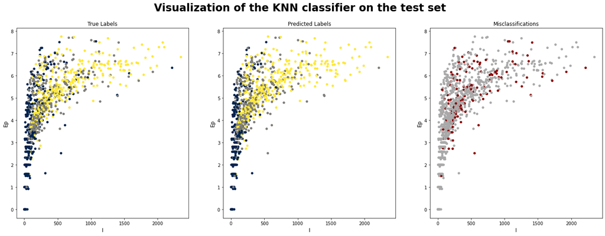

```python
classification_visualizer(test_set, test_label, test_pred_knn, 'KNN')
```

The comparison between the two plots (true labels and those predicted by the model) as well as the visualization of the misclassified points, allows us to note that **this model is quite accurate** as it did not make excessive errors in the prediction.

##### Confusion Matrix of the classifier

Here we display the confusion matrix referring to the classifier performance.

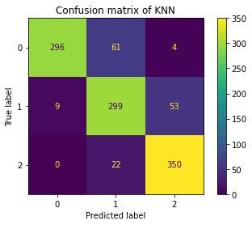

```python
plot_c_matrix(test_set, test_label, test_pred_knn, knn, 'KNN')
```

##### Visualization of the decision boundary of the classifier

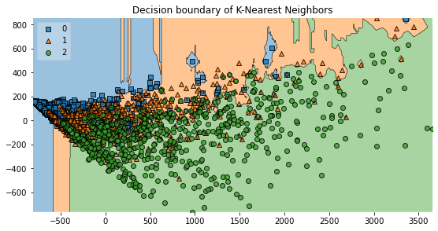

```python
plot_decision_boundary(train_set, train_label, knn, 'K-Nearest Neighbors')
```

The decision boundaries drawn by this model for our data are very precise: we will see, by comparing this plot with those of the following models, that the hyperplane found by knn to separate data into the three classes is one of the best in this notebook.

### Decision Tree

A non-parametric supervised learning method used for classification and regression The deeper the tree, the more complex the decision rules and the fitter the model.

scikit-learn uses an optimised version of the CART algorithm; however, scikit-learn implementation does not support categorical variables for now.

#### Import libraries

```python
from sklearn import tree
from scipy.stats import randint
```

#### Pre-processing

Consider performing dimensionality reduction (PCA, ICA, or Feature selection) beforehand to give your tree a better chance of finding features that are discriminative.

Remember that the number of samples required to populate the tree doubles for each additional level the tree grows to. Use max_depth to control the size of the tree to prevent overfitting.

Use min_samples_split or min_samples_leaf to ensure that multiple samples inform every decision in the tree, by controlling which splits will be considered. A very small number will usually mean the tree will overfit, whereas a large number will prevent the tree from learning the data For classification with few classes, min_samples_leaf=1 is often the best choice.

#### Grid search

Decision-tree learners can create over-complex trees that do not generalise the data well. This is called overfitting. Mechanisms such as pruning, setting the minimum number of samples required at a leaf node or setting the maximum depth of the tree are necessary to avoid this problem.

```python
from sklearn.model_selection import GridSearchCV, RandomizedSearchCV
from sklearn.metrics import make_scorer
from sklearn.metrics import accuracy_score
from sklearn.metrics import precision_score, recall_score
```

```python
dt_max_depth = [2,3,5,6,7,10,12, None]
dt_min_samples_split = randint(2, 51)
min_samples_leaf = randint(1, 51)
criterion = ["entropy", "gini"]
splitter = ["best", "random"]
max_features = [None, 2, 3, 4, 5]

dt_param_grid = {
    "max_depth": dt_max_depth,
    "min_samples_split": dt_min_samples_split,
    "min_samples_leaf": min_samples_leaf,
    "criterion": criterion,
    "splitter": splitter,
    "max_features": max_features
            }
```

```python
#define the number of iters (random combination to try)
n_iter_search = 500
```

```python
#define the number of jobs to run in parallel
n_jobs_search = -1
```

```python
#define the grid search
dt_grid = RandomizedSearchCV(tree.DecisionTreeClassifier(), param_distributions=dt_param_grid,
                            n_iter=n_iter_search,
                            n_jobs=n_jobs_search,
                            scoring=make_scorer(accuracy_score))
```

```python
dt_grid.fit(train_set, train_label)
```

```
RandomizedSearchCV(estimator=DecisionTreeClassifier(), n_iter=500, n_jobs=-1,
                   param_distributions={'criterion': ['entropy', 'gini'],
                                        'max_depth': [2, 3, 5, 6, 7, 10, 12,
                                                      None],
                                        'max_features': [None, 2, 3, 4, 5],
                                        'min_samples_leaf': <scipy.stats._distn_infrastructure.rv_frozen object at 0x00000269D75DB9D0>,
                                        'min_samples_split': <scipy.stats._distn_infrastructure.rv_frozen object at 0x00000269D75DB700>,
                                        'splitter': ['best', 'random']},
                   scoring=make_scorer(accuracy_score))
```

```python
print(dt_grid.best_params_)
```

```
{'criterion': 'entropy', 'max_depth': 12, 'max_features': None, 'min_samples_leaf': 11, 'min_samples_split': 7, 'splitter': 'best'}
```

#### Training

```python
dt = tree.DecisionTreeClassifier(**dt_grid.best_params_).fit(train_set, train_label)
```

```python
conda install graphviz
```

[output not shown]

[output cut: 57 more lines]

[output not shown]

```python
conda install -c conda-forge pydotplus
```

[output not shown]

```python
#visualize the actual decision tree obtained
import pydotplus
from IPython.display import Image
class_names=['low-spending', 'medium-spending', 'high-spending']
dot_data = tree.export_graphviz(dt, out_file=None,
                         feature_names=list(train_set.columns),
                         class_names=class_names,
                         filled=True, rounded=True)
graph = pydotplus.graph_from_dot_data(dot_data)
Image(graph.create_png())
```

[output not shown]

[output not shown]

#### Test

```python
train_pred_dt = dt.predict(train_set)
test_pred_dt = dt.predict(test_set)
```

#### Evaluation

##### Discussing the possibility of overfitting

```python
#evaulate the accuracy on the train set and the test set
#metrics also contains precision, recall, f1 and the support
from sklearn import metrics
print('Accuracy train set ', metrics.accuracy_score(train_label, train_pred_dt))
print('Accuracy test set ', metrics.accuracy_score(test_label, test_pred_dt))
```

```
Accuracy train set  0.9482758620689655
Accuracy test set  0.9387568555758684
```

##### Model performance on the training set

```python
report_scores(train_label,train_pred_dt)
```

```
                 precision    recall  f1-score   support

   low_spending       0.98      0.95      0.96       842
medium-spending       0.90      0.95      0.92       842
  high-spending       0.97      0.95      0.96       868

       accuracy                           0.95      2552
      macro avg       0.95      0.95      0.95      2552
   weighted avg       0.95      0.95      0.95      2552
```

##### Model performance on the test set

```python
report_scores(test_label,test_pred_dt)
```

```
                 precision    recall  f1-score   support

   low_spending       0.96      0.95      0.96       361
medium-spending       0.90      0.92      0.91       361
  high-spending       0.95      0.95      0.95       372

       accuracy                           0.94      1094
      macro avg       0.94      0.94      0.94      1094
   weighted avg       0.94      0.94      0.94      1094
```

##### Visualization of the classifier results via scatterplots

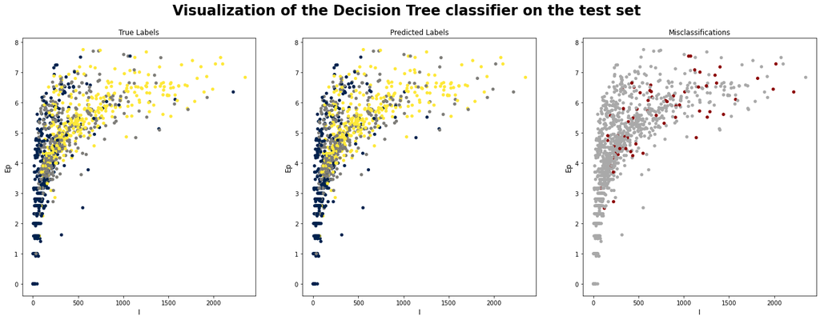

```python
classification_visualizer(test_set, test_label, test_pred_dt, 'Decision Tree')
```

The accuracy of this model is optimal, also for the test set.The misclassified points are very few. This leads us to argue that the **Decision Tree is one of the best candidates to be the best model for our data**.

##### Confusion Matrix of the classifier

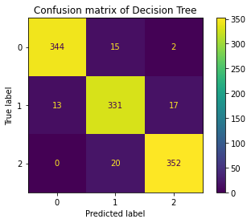

```python
plot_c_matrix(test_set, test_label, test_pred_dt, dt, 'Decision Tree')
```

There are very few errors in class attribution for this model.

##### Visualization of the decision boundary of the classifier

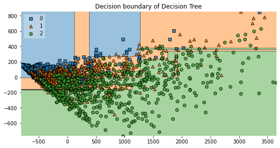

```python
plot_decision_boundary(train_set, train_label, dt, 'Decision Tree')
```

The decision boundaries traced by this model for our data are geometric and so not-curvilinear: besides their shape, they seem to be quite precise and accurate.

## Models

```python
knn = KNeighborsClassifier(**knn_grid.best_params_).fit(train_set, train_label)
dt = tree.DecisionTreeClassifier(**dt_grid.best_params_).fit(train_set, train_label)
```

## Predictions on test set

```python
test_pred_knn = knn.predict(test_set)
test_pred_dt = dt.predict(test_set)
```

## Evaluations

#### On test

```python
model = ['KNN', 'Decision Tree']
pred= [test_pred_knn, test_pred_dt ]


for i in range(len(pred)):
    print('\n', model[i])
    report_scores(test_label, pred[i])
```

```
 KNN
                 precision    recall  f1-score   support

   low_spending       0.97      0.82      0.89       361
medium-spending       0.78      0.83      0.80       361
  high-spending       0.86      0.94      0.90       372

       accuracy                           0.86      1094
      macro avg       0.87      0.86      0.86      1094
   weighted avg       0.87      0.86      0.86      1094


 Decision Tree
                 precision    recall  f1-score   support

   low_spending       0.96      0.95      0.96       361
medium-spending       0.90      0.92      0.91       361
  high-spending       0.95      0.95      0.95       372

       accuracy                           0.94      1094
      macro avg       0.94      0.94      0.94      1094
   weighted avg       0.94      0.94      0.94      1094
```

### Confusion matrices, decision boundaries

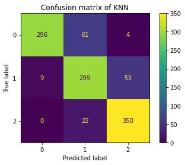

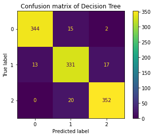

```python
fig = plt.figure(figsize=(20,15))
fig_dims = (2, 4)

title = ['KNN','Decision Tree']
pred= [test_pred_knn, test_pred_dt ]
model=[knn, dt]

for i in range(len(pred)):
    plot_c_matrix(test_set, test_label, pred[i], model[i], title[i])
```